# Blockchain on Twitter: A Sword of Damocles?

Shan Shan  
Dec 18 2017

### Blockchain

- Blockchain is the world's leading software platform for digital assets
- Google Trends shows that Blockchain has a boost in the year 2017
- What is Twitterers attitudes toward blockchain?

[figure not shown]

### A Helicopter view

[figure not shown]

### Blockchain -- Sword of Damocles?

> WHAT IS PEOPLE’S ATTITUDES TOWARDS BLOCKCHAIN?
- Some people regards Blockchain as a innovation : Blockchain: Shifting From Internet of Information to Internet of Value
- Some people regards Blockchain negatively and indicates its risks: The Dark Side of The Blockchain: What You Should Know About ICOs and the Ethereum Bubble

[figure not shown]

### Sentiment analysis with bing (positive list)

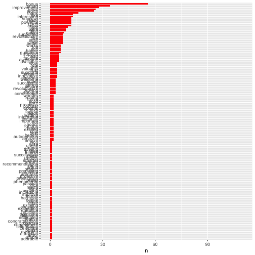

```r
poslist %>%
  mutate(word = reorder(word, n)) %>%
  ggplot(aes(word, n)) +
  geom_col(fill="red") +
  xlab(NULL) +
  coord_flip() +
  scale_y_continuous(limits = c(0,110))
```

### Sentiment analysis with bing (negtive list)

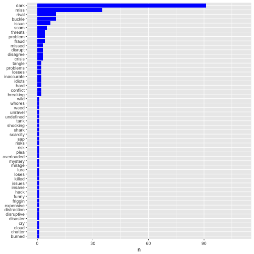

```r
neglist %>%
  mutate(word = reorder(word, n)) %>%
  ggplot(aes(word, n)) +
  geom_col(fill="blue") +
  xlab(NULL) +
  coord_flip() +
  scale_y_continuous(limits = c(0,110))
```

### Wordcloud

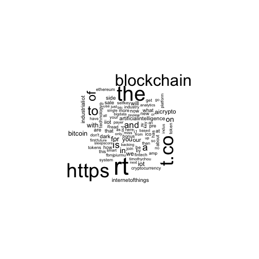

```r
library(wordcloud)


tidy_blch%>%
  count(word) %>%
  with(wordcloud(word, n, max.words = 100))
```

### Wordcloud (cont'd)

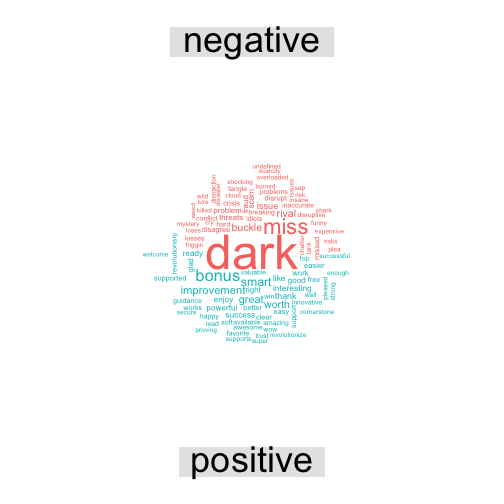

```r
  tidy_blch %>%
  inner_join(get_sentiments("bing")) %>%
  count(word, sentiment, sort = TRUE) %>%
  acast(word ~ sentiment, value.var = "n", fill = 0) %>%
  comparison.cloud(colors = c("#F8766D", "#00BFC4"),
                   max.words = 100)
```

[output not shown]

[figure not shown]

### Where are the blockchain twitterers?

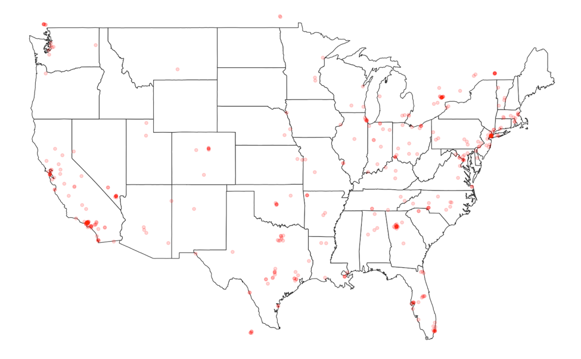

- The map displays that east part of U.S., such as New York; and the west part like California, have the most people twittering the blockchain topic

### Links of my project

SHINY APP

- https://shshan.shinyapps.io/blockchain_on_twitter/

GIT HUB

- https://github.com/shan-bu-2017/Twitterers-and-Blockchain.git